# MagdalenaOlbrys

## FIFA 22 football players.

Complete the following tasks using Python and/or R:

- Do explanatory data analysis and present three most interesting takeaways, that you will find in the data. You can illustrate the takeaways by using plots and / or summary tables.
- Choose features that can be most informative, when trying to estimate player’s value (“value_eur” column) and explain why.
- Prepare an executive summary for senior manager, who doesn’t understand data science concepts. Summary should consist of 2-4 bullet points explaining, which features are most important when trying to estimate player’s value.

```python
import pandas as pd
import seaborn as sns
import matplotlib.pyplot as plt
import numpy as np
from IPython.display import display, HTML
from sklearn.cluster import KMeans
```

```python
df = pd.read_csv('/Users/magdalenaolbrys/Desktop/visa/df_players.csv', sep=';')
```

## BASIC INFO ABOUT DATASET:

```python
df.head()
```

|  | Unnamed: 0 | sofifa_id | short_name | overall | potential | age | height_cm | weight_kg | club_name | league_name | ... | preferred_foot | pace | shooting | passing | dribbling | defending | physic | formation | player_tags | value_eur |
| --- | --- | --- | --- | --- | --- | --- | --- | --- | --- | --- | --- | --- | --- | --- | --- | --- | --- | --- | --- | --- | --- |
| 0 | 1 | 255438 | R. Araki | 67 | 80 | 19 | 170 | 60 | Kashima Antlers | Japanese J. League Division 1 | ... | Right | 83.0 | 61.0 | 61.0 | 72.0 | 22.0 | 43.0 | mid | NaN | 2400000 |
| 1 | 2 | 246070 | Iván Jaime | 70 | 82 | 20 | 180 | 73 | Futebol Clube de Famalicão | Portuguese Liga ZON SAGRES | ... | Right | 72.0 | 70.0 | 65.0 | 71.0 | 50.0 | 60.0 | mid | NaN | 3800000 |
| 2 | 3 | 203173 | Noguera | 68 | 68 | 31 | 177 | 65 | FC Goa | Indian Super League | ... | Right | 75.0 | 62.0 | 67.0 | 69.0 | 57.0 | 59.0 | mid | NaN | 1e+06 |
| 3 | 4 | 178090 | D. Biseswar | 75 | 75 | 33 | 176 | 79 | PAOK | Greek Super League | ... | Right | 71.0 | 69.0 | 76.0 | 78.0 | 33.0 | 60.0 | mid | NaN | 3500000 |
| 4 | 5 | 223978 | Manu García | 73 | 82 | 23 | 169 | 66 | Deportivo Alavés | Spain Primera Division | ... | Right | 78.0 | 69.0 | 72.0 | 75.0 | 40.0 | 56.0 | mid | NaN | 7e+06 |

5 rows × 21 columns

```python
df.info()
```

```
<class 'pandas.core.frame.DataFrame'>
RangeIndex: 5969 entries, 0 to 5968
Data columns (total 21 columns):
 #   Column                     Non-Null Count  Dtype
---  ------                     --------------  -----
 0   Unnamed: 0                 5969 non-null   int64
 1   sofifa_id                  5969 non-null   int64
 2   short_name                 5969 non-null   object
 3   overall                    5969 non-null   int64
 4   potential                  5969 non-null   int64
 5   age                        5969 non-null   int64
 6   height_cm                  5969 non-null   int64
 7   weight_kg                  5969 non-null   int64
 8   club_name                  5969 non-null   object
 9   league_name                5969 non-null   object
 10  club_contract_valid_until  5969 non-null   int64
 11  preferred_foot             5969 non-null   object
 12  pace                       5426 non-null   float64
 13  shooting                   5426 non-null   float64
 14  passing                    5426 non-null   float64
 15  dribbling                  5426 non-null   float64
 16  defending                  5426 non-null   float64
 17  physic                     5426 non-null   float64
 18  formation                  5969 non-null   object
 19  player_tags                710 non-null    object
 20  value_eur                  5969 non-null   object
dtypes: float64(6), int64(8), object(7)
memory usage: 979.4+ KB
```

## NUMERICAL VALUES:

## Feature 'value_eur'

seems to be a numeric variable but its type is object. let's try to change it

```python
df['value_eur'] = pd.to_numeric(df['value_eur'], errors='coerce')
```

```python
df[['value_eur']].info()
```

```
<class 'pandas.core.frame.DataFrame'>
RangeIndex: 5969 entries, 0 to 5968
Data columns (total 1 columns):
 #   Column     Non-Null Count  Dtype
---  ------     --------------  -----
 0   value_eur  5641 non-null   float64
dtypes: float64(1)
memory usage: 46.8 KB
```

## Feature 'club_contract_value_until'

```python
df['club_contract_valid_until'].unique()

# df['remaining_contract_years'] = df['club_contract_valid_until'] - pd.Timestamp.now().year
```

```
array([2022, 2025, 2023, 2024, 2026, 2021, 2027, 2028, 2031])
```

I'm not sure if it makes sense to refer it to the current date, so we ignore this feature

```python
# creating df with numerical features only
df_numerical = df[['overall', 'potential', 'age', 'height_cm', 'weight_kg', 'pace', 'shooting', 'passing', 'dribbling', 'defending', 'physic', 'value_eur']]
```

## Features 'Unnamed: 0' and 'sofifa_id'

these are identifiers so let's skip them

## CATEGORICAL VALUES:

## Features 'club_name' and 'league_name’

```python
print(f" We have {df['club_name'].nunique()} different clubs and {df['league_name'].nunique()} leagues \n 5969 players in the dataset")
```

```
 We have 543 different clubs and 46 leagues
 5969 players in the dataset
```

## Feature 'formation'

```python
df['formation'].unique()
```

```
array(['mid', 'def', 'att', 'GK'], dtype=object)
```

## Feature 'player_tags'

```python
df['player_tags'].nunique()
```

```
65
```

## Feature 'preferred_foot'

```python
df['preferred_foot'].unique()
```

```
array(['Right', 'Left'], dtype=object)
```

```python
df['preferred_foot'] = df['preferred_foot'].map({'Right': 0, 'Left': 1})
```

## MISSING VALUES:

```python
df.isnull().sum()
```

```
Unnamed: 0                      0
sofifa_id                       0
short_name                      0
overall                         0
potential                       0
age                             0
height_cm                       0
weight_kg                       0
club_name                       0
league_name                     0
club_contract_valid_until       0
preferred_foot                  0
pace                          543
shooting                      543
passing                       543
dribbling                     543
defending                     543
physic                        543
formation                       0
player_tags                  5259
value_eur                     328
dtype: int64
```

there are some values missing in the dataframe but let's ignore them for now

## FEATURES DISTRIBUTIONS:

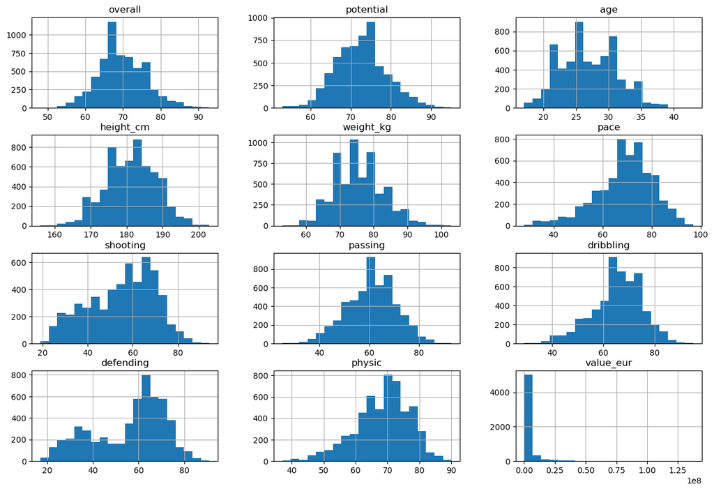

```python
df_numerical.hist(bins=20, figsize=(15, 10))
plt.show()
```

## The distribution of the “defending” featur seems to be bimodal.

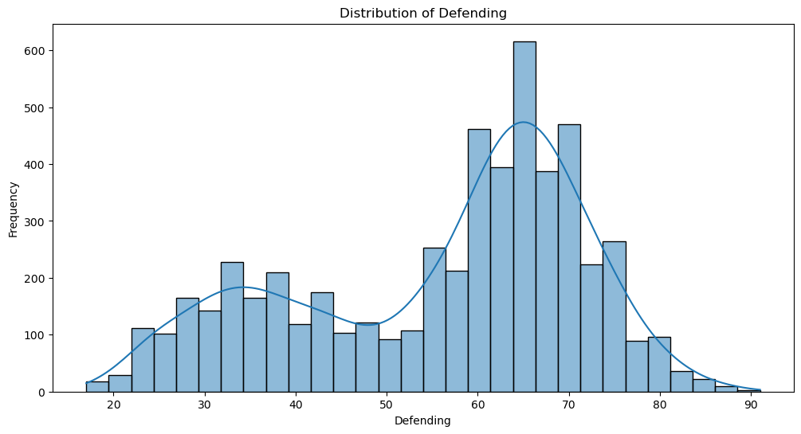

```python
defending = df['defending']

plt.figure(figsize=(12, 6))
sns.histplot(defending, kde=True, bins=30)
plt.title('Distribution of Defending')
plt.xlabel('Defending')
plt.ylabel('Frequency')
plt.show()
```

# FIRST CONCLUSION OF EXPLANATORY DATA ANALYSIS:

## We can split the data into two groups: one representing players with lower defense skills and one with higher skills. This segmentation can help in further analyses.

```python
print(f" There is {round(df['defending'].isna().sum() / df['defending'].sum() * 100, 2)} % missing values in 'defending' feature")
```

[output not shown]

so we can drop these observations.

```python
df_cleaned = df.dropna(subset = ['defending'])
```

## Segmentation using the k-means algorithm

```
Group 1: 3700 players
Group 2: 1726 players
```

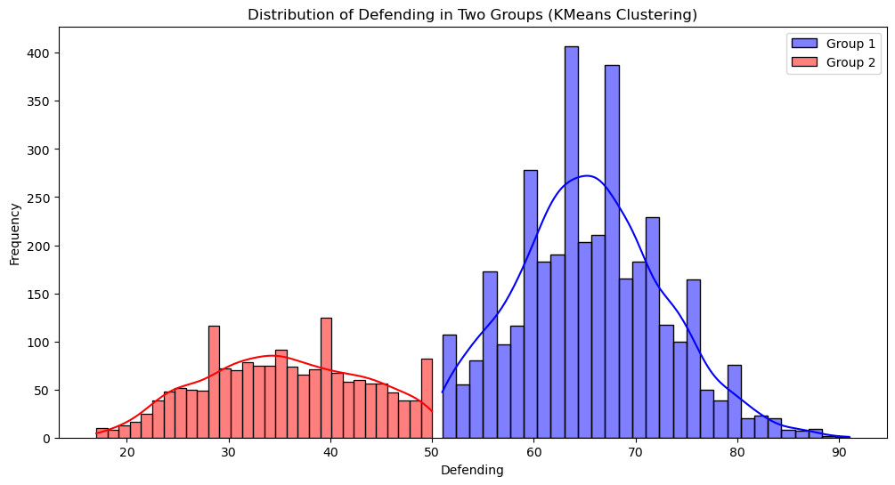

```python
df_cleaned = df_cleaned.copy()

# applying KMeans clustering with 2 clusters
defending = df_cleaned['defending'].values.reshape(-1, 1)
kmeans = KMeans(n_clusters=2, random_state=42)

# assigning cluster labels to the dataframe
df_cleaned['cluster'] = kmeans.fit_predict(defending)

# the size of each cluster
group1 = df_cleaned[df_cleaned['cluster'] == 0]
group2 = df_cleaned[df_cleaned['cluster'] == 1]

print(f"Group 1: {group1.shape[0]} players")
print(f"Group 2: {group2.shape[0]} players")

# plot
plt.figure(figsize=(12, 6))
sns.histplot(group1['defending'], kde=True, color='blue', label='Group 1', bins=30)
sns.histplot(group2['defending'], kde=True, color='red', label='Group 2', bins=30)

plt.title('Distribution of Defending in Two Groups (KMeans Clustering)')
plt.xlabel('Defending')
plt.ylabel('Frequency')
plt.legend()
plt.show()
```

## C0RRELATIONS:

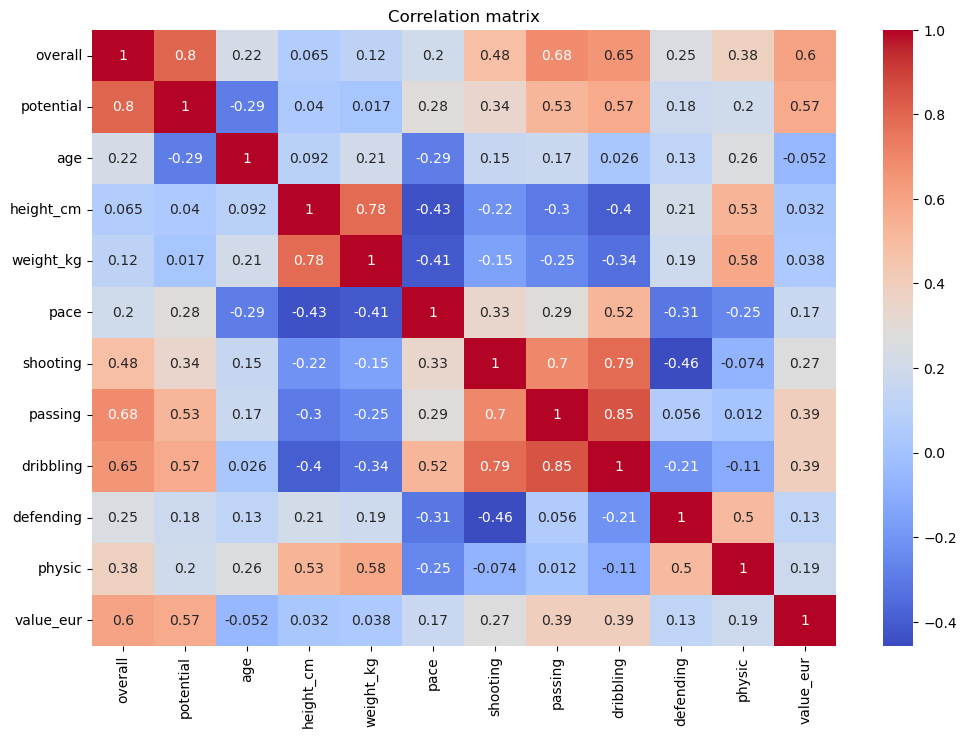

```python
plt.figure(figsize=(12, 8))
sns.heatmap(df_numerical.corr(), annot=True, cmap='coolwarm')
plt.title("Correlation matrix")
plt.show()
```

## Strong correlations:

# SECOND CONCLUSION OF EXPLANATORY DATA ANALYSIS:

## Dribbling and passing are strongly positively correlated, while defending is negatively correlated with shooting and pace. These are clear patterns that define the division and various roles of players.

## CATEGORICAL VALUES DISTRIBUTIONS:

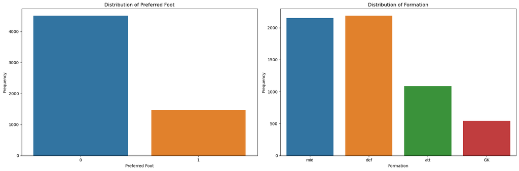

```python
plt.figure(figsize=(18, 6))

plt.subplot(1, 2, 1)
sns.countplot(x=df['preferred_foot'])
plt.title('Distribution of Preferred Foot')
plt.xlabel('Preferred Foot')
plt.ylabel('Frequency')

plt.subplot(1, 2, 2)
sns.countplot(x=df['formation'])
plt.title('Distribution of Formation')
plt.xlabel('Formation')
plt.ylabel('Frequency')

plt.tight_layout()
plt.show()
```

The dataset shows that more players prefer using their right foot(0 at chart) than left foot (1), which reflects real-world tendencies. (this finding holds true only for this specific feature).

# THIRD CONCLUSION OF EXPLANATORY DATA ANALYSIS

## In this dataset, there is a similar number of midfielders and defenders, with attackers making up about half as many. Goalkeepers are the least represented.

## FEATURES TO ESTIMATE PLAYER’S VALUE

```python
df_numerical.corr()[['value_eur']]
```

|  | value_eur |
| --- | --- |
| overall | 0.597652 |
| potential | 0.572518 |
| age | -0.052496 |
| height_cm | 0.031929 |
| weight_kg | 0.038267 |
| pace | 0.167394 |
| shooting | 0.271722 |
| passing | 0.394441 |
| dribbling | 0.392434 |
| defending | 0.126729 |
| physic | 0.185324 |
| value_eur | 1.000000 |

# FEATURES THAT CAN BE MOST INFORMATIVE, WHEN TRYING TO ESTIMATE PLAYER’S VALUE:

To estimate a player's value, the most informative features (based on correlation) are:

- overal (0.60): a high overall score directly reflects a player’s skill level and performance
- potential (0.57): potential indicates future growth, which makes players with high potential especially valuable as they could significantly increase in skill and worth
- passing (0.39): strong passing skills are crucial for teamwork and effective play, which can enhance a player’s contribution
- dribbling (0.39): good dribbling showcases control and ability to maintain possession, making a player versatile and desirable
- shooting (0.27): shooting is key for scoring, which is vital in winning games
- physic (0.19): physical strength contributes to a player’s endurance and resilience, important in high-performance situations
- pace (0.17): speed can be crucial in both offensive and defensive plays, increasing a player’s effectiveness and value
- defending (0.13): strong defending skills are crucial for maintaining team stability, enhancing a player’s utility on the field

These features have the strongest correlations with value, making them key to estimating a player's market worth. Lower correlations of pace and defending with value may suggest that players in defensive roles are generally less valued financially. However, each of the above features is still relevant, as they all capture important aspects of a player's skill and contribute to their overall impact on the game. Thus, despite the lower emphasis on defensive metrics, these features remain significant in assessing a player’s worth.

# SUMMARY FOR SENIOR MANAGER:

## 1. Introduction

The FIFA 22 football players data contains information on 5969 players, including both categorical features such as club name, league, preferred foot, and formation, as well as numerical features such as skill ratings, age, height, weight, and market value. Numerical variables include "overall", "potential", and technical statistics (e.g., shooting, dribbling), while categorical features relate to attributes associated with the player's club and personal preferences.

## 2. Correlations between numerical features and Player's Value

Correlation means that two features change in a similar way. Features that have a high correlation with the predicted feature indicate that changes in these features directly impact the predicted value. Therefore, if we want to accurately predict a given feature, we need to consider those that are strongly correlated.

In our data, the highest correlation coefficients with the player’s value are for the overall and potential features. While we don't know exactly how they are calculated, we can assume that they are derived based on other player parameters (e.g., defending, shooting, dribbling).

The plot below shows the correlation coefficient of players' value with other numerical features from our dataset.

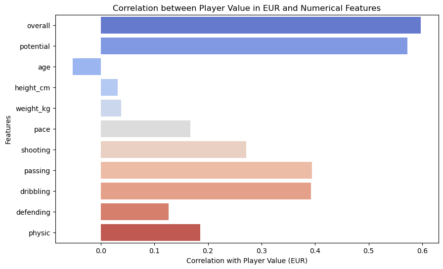

```python
corr_data = {
    'Feature': ['overall', 'potential', 'age', 'height_cm', 'weight_kg', 'pace',
                'shooting', 'passing', 'dribbling', 'defending', 'physic'],
    'Correlation': [0.597652, 0.572518, -0.052496, 0.031929, 0.038267, 0.167394,
                    0.271722, 0.394441, 0.392434, 0.126729, 0.185324]
}


corr_df = pd.DataFrame(corr_data)


plt.figure(figsize=(10, 6))
sns.barplot(x='Correlation', y='Feature', data=corr_data, palette='coolwarm')
plt.title('Correlation between Player Value in EUR and Numerical Features')
plt.xlabel('Correlation with Player Value (EUR)')
plt.ylabel('Features')
plt.show()
```

# 3. Significance of categorical features

A violin plot is a way of presenting data that shows how different values(e.g. market value of players) are distributed in different groups (e.g. player positions, preffered foot).

A wider shape on a violin plot for a given category indicates greater variability in market value within that category. This means that the market values of players in this group are more spread out (e.g., there are both very expensive and cheaper players).

Conversely, a narrower shape suggests that the market values of players in this category are more uniform and concentrated around a single value.

The plots below show the market value of players in given groups (due to the player's role - left plot chart and preferred foot - right plot)

[figure not shown]

```python
fig, axes = plt.subplots(1, 2, figsize=(14, 6))

sns.violinplot(x='formation', y='value_eur', data=df, ax=axes[0])
axes[0].set_title('Value of Player by Formation')

sns.violinplot(x='preferred_foot', y='value_eur', data=df, ax=axes[1])
axes[1].set_title('Value of Player by Preferred Foot')
axes[1].set_xticklabels(['left', 'right'])

plt.tight_layout()
plt.show()
```

## 4. Conclusion and Next Steps

The analysis of both numerical and categorical features provides valuable insights into the factors that influence a player's market value. Understanding the correlation between player ratings (overall and potential) and their value can help identify key drivers of market pricing. Additionally, the insights gained from examining player roles and preferences (such as formation and preferred foot) can guide decisions in player evaluation. These findings will be instrumental in refining strategies for player acquisition and valuation, and can serve as a foundation for more detailed predictive models and further analyses.